# CodonProfiler: analyze codon usage patterns across transcriptome

Kai Hu, Haibo Liu, Richard Gregory and Lihua Julie Zhu

Molecular, Cell and Cancer Biology, University of Massachusetts Medical School, Worcester, MA, USA

15 August 2025

#### Abstract

Instructions on using *CodonProfiler* for codon usage analysis.

#### Package

CodonProfiler 0.1.0

# 1 Introduction

Codon usage bias, or simply codon bias, refers to the non-random preference for synonymous codons encoding the same amino acid. Genomic codon bias reflects the inherent codon composition encoded in the genome, shaped over evolutionary time by mutations and natural selection. In contrast, transcriptomic codon bias captures the dynamic usage of codons in expressed mRNAs, influenced by factors such as tRNA availability, translation efficiency, and mRNA stability.

While several tools and databases exist for calculating and visualizing various codon usage metrics, integrating codon usage information into biological discovery remains challenging, especially when working with transcriptome-level data or mutation-rich samples, such as those derived from cancer studies. The *CodonProfiler* package addresses these challenges by providing a comprehensive and flexible toolkit that streamlines common codon usage analyses. It supports calculation of diverse codon usage metrics, with optional TPM weighting; incorporates mutation-aware analyses using variant data; and enables pathway-level assessments of codon usage differences across biological conditions or disease states.

The core features and a typical workflow using *CodonProfiler* for codon usage analysis are summarized in the diagram below. Detailed examples demonstrating the package’s capabilities are presented in the A Typical Workflow section.

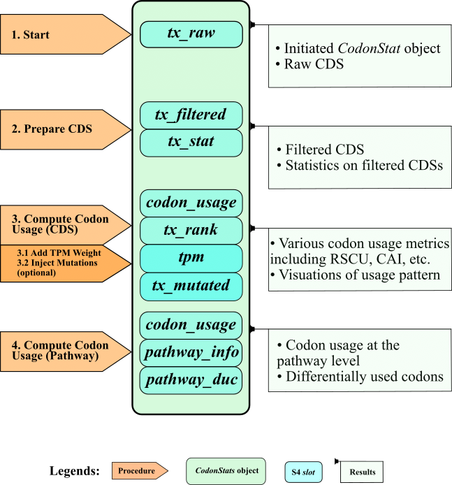

Figure 1: A typical workflow using CodonProfiler

# 2 Installation

```r
library(devtools)

install_github("hukai916/CodonProfiler")
```

# 3 Quick start

A `CodonStats` object serves as the core data container for codon usage analysis in this package. We can create one using the `CodonStats()` constructor by specifying a genome assembly name, currently supported genomes include “mm10” (mouse) and “hg38” (human). The constructor initializes a `CodonStats` object with a `tx_raw` slot that holds all raw transcript retrieved from the `EnsDb` database for the chosen genome.

```r
library(CodonProfiler)
csm <- CodonStats("mm10")
```

```
## Creating `CodonStats` object ...
```

```
##   Note: 267 transcript(s) are excluded as their seqnames do not appear in the genome.
## Creating `CodonStats` object: done!
```

```r
head(tx_raw(csm))
```

```
## # A tibble: 6 × 7
##   GENEID             GENENAME TXID               TXBIOTYPE    SEQ   WIDTH STRAND
##   <chr>              <chr>    <chr>              <chr>        <chr> <int> <chr>
## 1 ENSMUSG00000000001 Gnai3    ENSMUST00000000001 protein_cod… ATGG…  1065 -
## 2 ENSMUSG00000000003 Pbsn     ENSMUST00000000003 protein_cod… ATGA…   525 -
## 3 ENSMUSG00000020875 Hoxb9    ENSMUST00000000010 protein_cod… ATGT…   753 +
## 4 ENSMUSG00000000028 Cdc45    ENSMUST00000000028 protein_cod… ATGT…  1701 -
## 5 ENSMUSG00000048583 Igf2     ENSMUST00000000033 protein_cod… ATGG…   543 -
## 6 ENSMUSG00000000049 Apoh     ENSMUST00000000049 protein_cod… ATGG…  1038 +
```

We can apply filters using `set_tx_filter()` to retain only valid transcripts. By default, this keeps protein-coding transcripts that have a valid start codon, a valid stop codon, and a CDS length divisible by three. The applied filters are stored in the `tx_filter` slot. Next, we populate the `tx_filtered` slot with the transcripts that pass these filters by calling `set_tx_filtered()`. These filtered transcripts are then used for downstream analyses.

```r
# Add desired CDS filters
csm <- set_tx_filter(csm,
                     value = c("protein_coding",
                               "start_codon",
                               "stop_codon",
                               "three_multiplier"))

# Show added filters
tx_filter(csm)
```

```
## [1] "protein_coding"   "start_codon"      "stop_codon"       "three_multiplier"
```

```r
# Apply filters
csm <- set_tx_filtered(csm)
head(tx_filtered(csm))
```

```
## # A tibble: 6 × 7
##   GENEID             GENENAME TXID               TXBIOTYPE    SEQ   WIDTH STRAND
##   <chr>              <chr>    <chr>              <chr>        <chr> <int> <chr>
## 1 ENSMUSG00000000001 Gnai3    ENSMUST00000000001 protein_cod… ATGG…  1065 -
## 2 ENSMUSG00000000003 Pbsn     ENSMUST00000000003 protein_cod… ATGA…   525 -
## 3 ENSMUSG00000020875 Hoxb9    ENSMUST00000000010 protein_cod… ATGT…   753 +
## 4 ENSMUSG00000000028 Cdc45    ENSMUST00000000028 protein_cod… ATGT…  1701 -
## 5 ENSMUSG00000048583 Igf2     ENSMUST00000000033 protein_cod… ATGG…   543 -
## 6 ENSMUSG00000000049 Apoh     ENSMUST00000000049 protein_cod… ATGG…  1038 +
```

Next, we compute a variety of codon usage metrics from the filtered transcripts using `set_codon_usage()`. The results are organized as a list of tibbles stored in the `codon_usage` slot, with each tibble representing a distinct set of codon usage metrics.

```r
csm <- set_codon_usage(csm)

names(codon_usage(csm))
```

```
##  [1] "use_tx"                         "use_tpm_weighted"
##  [3] "global"                         "global_normalized"
##  [5] "global_rscu"                    "per_tx"
##  [7] "per_tx_normalized_by_tx_length" "per_tx_normalized_by_global"
##  [9] "per_tx_milc"                    "per_tx_enc"
## [11] "per_tx_enc_prime"               "per_tx_rscu"
## [13] "per_tx_cai"
```

```r
head(codon_usage(csm)$global)
```

```
##    AAA    AAC    AAG    AAT    ACA    ACC
## 481957 416698 707147 330957 336970 380236
```

# 4 A typical workflow

The following examples demonstrate a typical workflow using *CodonProfiler* to analyze codon usage, with a focus on uncovering biological insights from codon usage patterns. This workflow involves four main steps:

- Initialize a `CodonStats` object
- Prepare coding sequence (CDS)
- Compute codon usage
- Compute pathway-level codon usage

## 4.1 Step1: Initialize a `CodonStats` object

Creating a `CodonStats` object is as simple as passing the desired genome name to the `CodonStats()` constructor. The resulting object, `csm`, contains a slot named `tx_raw` that holds all raw transcripts retrieved from `EnsDb`.

```r
csm <- CodonStats("mm10")
```

```
## Creating `CodonStats` object ...
##   Note: 267 transcript(s) are excluded as their seqnames do not appear in the genome.
## Creating `CodonStats` object: done!
```

```r
head(tx_raw(csm))
```

```
## # A tibble: 6 × 7
##   GENEID             GENENAME TXID               TXBIOTYPE    SEQ   WIDTH STRAND
##   <chr>              <chr>    <chr>              <chr>        <chr> <int> <chr>
## 1 ENSMUSG00000000001 Gnai3    ENSMUST00000000001 protein_cod… ATGG…  1065 -
## 2 ENSMUSG00000000003 Pbsn     ENSMUST00000000003 protein_cod… ATGA…   525 -
## 3 ENSMUSG00000020875 Hoxb9    ENSMUST00000000010 protein_cod… ATGT…   753 +
## 4 ENSMUSG00000000028 Cdc45    ENSMUST00000000028 protein_cod… ATGT…  1701 -
## 5 ENSMUSG00000048583 Igf2     ENSMUST00000000033 protein_cod… ATGG…   543 -
## 6 ENSMUSG00000000049 Apoh     ENSMUST00000000049 protein_cod… ATGG…  1038 +
```

## 4.2 Step2: Prepare coding sequence (CDS)

```r
# Add desired filters
csm <- set_tx_filter(csm)

# Apply filters
csm <- set_tx_filtered(csm)
head(tx_filtered(csm))
```

```
## # A tibble: 6 × 7
##   GENEID             GENENAME TXID               TXBIOTYPE    SEQ   WIDTH STRAND
##   <chr>              <chr>    <chr>              <chr>        <chr> <int> <chr>
## 1 ENSMUSG00000000001 Gnai3    ENSMUST00000000001 protein_cod… ATGG…  1065 -
## 2 ENSMUSG00000000003 Pbsn     ENSMUST00000000003 protein_cod… ATGA…   525 -
## 3 ENSMUSG00000020875 Hoxb9    ENSMUST00000000010 protein_cod… ATGT…   753 +
## 4 ENSMUSG00000000028 Cdc45    ENSMUST00000000028 protein_cod… ATGT…  1701 -
## 5 ENSMUSG00000048583 Igf2     ENSMUST00000000033 protein_cod… ATGG…   543 -
## 6 ENSMUSG00000000049 Apoh     ENSMUST00000000049 protein_cod… ATGG…  1038 +
```

We can check, for each transcript, how many filters it passes using `set_tx_stat()`, which stores the results in the `tx_stat` slot, and visualize the results using `plot_tx_stat()`. When applying filters, instead of removing incomplete transcripts, e.g. those missing start codon or stop codon, we can attempt to rescue them by setting `set_tx_filtered(rescue_incomplete_cds = TRUE)`, type `?set_tx_filtered` for more details.

```r
library(dplyr)
```

```r
csm <- set_tx_stat(csm)

tx_stat(csm)$tx_raw %>%
  select(c(TXID, tx_filter(csm))) %>%
  head()
```

```
## # A tibble: 6 × 5
##   TXID               start_codon stop_codon three_multiplier protein_coding
##   <chr>              <lgl>       <lgl>      <lgl>            <lgl>
## 1 ENSMUST00000000001 TRUE        TRUE       TRUE             TRUE
## 2 ENSMUST00000000003 TRUE        TRUE       TRUE             TRUE
## 3 ENSMUST00000000010 TRUE        TRUE       TRUE             TRUE
## 4 ENSMUST00000000028 TRUE        TRUE       TRUE             TRUE
## 5 ENSMUST00000000033 TRUE        TRUE       TRUE             TRUE
## 6 ENSMUST00000000049 TRUE        TRUE       TRUE             TRUE
```

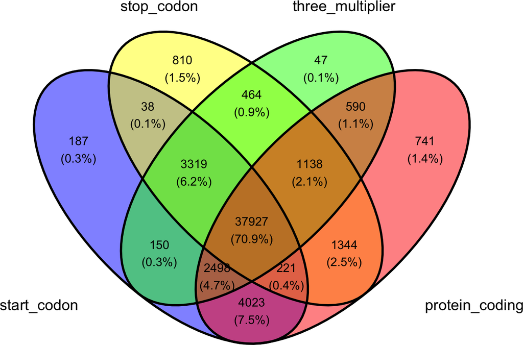

```r
plot_tx_stat(csm)
```

The Venn diagram shows that about 70% of transcript are retained after filtering. Addtionally, the “selected_tx” filter enables users to specify particular transcripts for analysis. This is useful when focusing on specific genes or pathways of interest. We can apply this filter using the following command. Note that the “selected_tx” filter can be combined with other filters.

```r
selected_tx <- c("ENSMUST00000000001",
                  "ENSMUST00000000003",
                  "ENSMUST00000000010",
                  "ENSMUST00000000028",
                  "ENSMUST00000000033",
                  "ENSMUST00000000049")
csm_demo <- set_tx_filter(csm,
                          value = "selected_tx",
                          selected_tx = selected_tx)
csm_demo <- set_tx_filtered(csm_demo)
dim(tx_filtered(csm_demo))
```

[output not shown]

## 4.3 Step3: Calculate codon usage

After obtaining the filtered transcripts, we can calculate codon usage using `set_codon_usage()`. The results are stored as a list of tibbles in the `codon_usage` slot, each tibble containing distinct codon usage metrics. By default, the following metrics are computed:

- `global`: Raw codon counts for each codon across the entire transcriptome.
- `global_normalized`: Normalized `global`, where codon counts are divided by the total codon count. This serves as a background codon usage profile useful for cross-genome comparisons.
- `global_rscu`: The Relative Synonymous Codon Usage (RSCU) values calculated from `global`.
- `per_tx`: Raw codon counts for each codon within every transcript.
- `per_tx_normalized_by_tx_length`: `per_tx` counts normalized by transcript length (i.e., codon counts divided by transcript length).
- `per_tx_normalized_by_global`: Further normalization of `per_tx_normalized_by_tx_length` by dividing against `global_normalized` for each codon.
- `per_tx_milc`: Measure Independent of Length and Composition (MILC) score for each transcript, which quantifies codon usage bias while accounting for sequence length and composition.
- `per_tx_enc`: Effective Number of Codons (ENC) score for each transcript, which measures the degree of codon usage bias.
- `per_tx_enc_prime`: The ENCprime score for each transcript, an improved version of ENC that better handles extreme codon usage bias.
- `per_tx_rscu`: RSCU values calculated at each transcript level.

If you set `include_CAI = TRUE`, the following metric is also calculated:

- `per_tx_cai`: The Codon Adaptation Index (CAI) score for each transcript, which quantifies codon usage bias relative to that observed in highly expressed gene sets.

```r
csm <- set_codon_usage(csm)

# View the raw global codon counts
codon_usage(csm)$global %>% head()
```

```
##    AAA    AAC    AAG    AAT    ACA    ACC
## 481957 416698 707147 330957 336970 380236
```

```r
# View the raw per-transcript codon counts
codon_usage(csm)$per_tx %>% head()
```

```
## # A tibble: 6 × 65
##   TXID     AAA   AAC   AAG   AAT   ACA   ACC   ACG   ACT   AGA   AGC   AGG   AGT
##   <chr>  <int> <int> <int> <int> <int> <int> <int> <int> <int> <int> <int> <int>
## 1 ENSMU…    17     8    11     6     8     7     2     6     5     6     3     4
## 2 ENSMU…     8     5    10     5     3     2     2     1     4     2     3     3
## 3 ENSMU…     9     4     7     5     0     4     3     1     3     8     5     3
## 4 ENSMU…     8    12    25     7     8    10     2     9     3    11     9     6
## 5 ENSMU…     4     2     3     0     1     3     1     1     4     5     2     0
## 6 ENSMU…    10     7    17     6     8     8     5     3     5     3     4     3
## # ℹ 52 more variables: ATA <int>, ATC <int>, ATG <int>, ATT <int>, CAA <int>,
## #   CAC <int>, CAG <int>, CAT <int>, CCA <int>, CCC <int>, CCG <int>,
## #   CCT <int>, CGA <int>, CGC <int>, CGG <int>, CGT <int>, CTA <int>,
## #   CTC <int>, CTG <int>, CTT <int>, GAA <int>, GAC <int>, GAG <int>,
## #   GAT <int>, GCA <int>, GCC <int>, GCG <int>, GCT <int>, GGA <int>,
## #   GGC <int>, GGG <int>, GGT <int>, GTA <int>, GTC <int>, GTG <int>,
## #   GTT <int>, TAA <int>, TAC <int>, TAG <int>, TAT <int>, TCA <int>, …
```

```r
# View the per-transcript RSCU values
codon_usage(csm)$per_tx_rscu %>% head()
```

```
## # A tibble: 6 × 65
##   TXID     AAA   AAC   AAG   AAT   ACA   ACC   ACG   ACT   AGA   AGC   AGG   AGT
##   <chr>  <dbl> <dbl> <dbl> <dbl> <dbl> <dbl> <dbl> <dbl> <dbl> <dbl> <dbl> <dbl>
## 1 ENSMU… 1.21  1.14  0.786 0.857 1.39   1.22 0.348 1.04   1.5   1.64  0.9   1.09
## 2 ENSMU… 0.889 1     1.11  1     1.5    1    1     0.5    2.4   1.71  1.8   2.57
## 3 ENSMU… 1.12  0.889 0.875 1.11  0      2    1.5   0.5    1.06  2     1.76  0.75
## 4 ENSMU… 0.485 1.26  1.52  0.737 1.10   1.38 0.276 1.24   0.6   1.38  1.8   0.75
## 5 ENSMU… 1.14  2     0.857 0     0.667  2    0.667 0.667  1.2   1.88  0.6   0
## 6 ENSMU… 0.741 1.08  1.26  0.923 1.33   1.33 0.833 0.5    2.14  0.9   1.71  0.9
## # ℹ 52 more variables: ATA <dbl>, ATC <dbl>, ATG <dbl>, ATT <dbl>, CAA <dbl>,
## #   CAC <dbl>, CAG <dbl>, CAT <dbl>, CCA <dbl>, CCC <dbl>, CCG <dbl>,
## #   CCT <dbl>, CGA <dbl>, CGC <dbl>, CGG <dbl>, CGT <dbl>, CTA <dbl>,
## #   CTC <dbl>, CTG <dbl>, CTT <dbl>, GAA <dbl>, GAC <dbl>, GAG <dbl>,
## #   GAT <dbl>, GCA <dbl>, GCC <dbl>, GCG <dbl>, GCT <dbl>, GGA <dbl>,
## #   GGC <dbl>, GGG <dbl>, GGT <dbl>, GTA <dbl>, GTC <dbl>, GTG <dbl>,
## #   GTT <dbl>, TAA <dbl>, TAC <dbl>, TAG <dbl>, TAT <dbl>, TCA <dbl>, …
```

Transcripts can be ranked according to per-transcript based metrics, such as “enc”, “enc_prime”, “cai”, and “milc”:

```r
# View the top ten transcripts with the lowest ENC (most biased)
codon_usage(csm)$per_tx_enc %>%
  arrange(ENC) %>%
  head(10)
```

```
## # A tibble: 10 × 2
##    TXID                 ENC
##    <chr>              <dbl>
##  1 ENSMUST00000176483  23.0
##  2 ENSMUST00000082065  24.7
##  3 ENSMUST00000034215  25.2
##  4 ENSMUST00000102965  25.8
##  5 ENSMUST00000059845  26.0
##  6 ENSMUST00000138892  26.2
##  7 ENSMUST00000102983  26.4
##  8 ENSMUST00000091742  26.6
##  9 ENSMUST00000087714  26.7
## 10 ENSMUST00000188005  26.9
```

In addtion to ranking by per-transcript metrics, we can use per-codon metrics, such as “raw count” and “normalized count”, to identify and visualize transcripts that are most enriched in a specific codon.

```r
# View top 10 transcripts with the highest raw count for the codon "AAA"
codon_usage(csm)$per_tx %>%
  arrange(desc(AAA)) %>%
  head(10)
```

```
## # A tibble: 10 × 65
##    TXID    AAA   AAC   AAG   AAT   ACA   ACC   ACG   ACT   AGA   AGC   AGG   AGT
##    <chr> <int> <int> <int> <int> <int> <int> <int> <int> <int> <int> <int> <int>
##  1 ENSM…  1648   546  1390   559   887   758   217   759   632   515   314   447
##  2 ENSM…  1563   538  1306   549   840   719   209   718   607   506   301   429
##  3 ENSM…  1562   538  1307   549   840   719   209   718   607   506   301   429
##  4 ENSM…  1163   437  1000   464   725   603   168   604   531   393   263   348
##  5 ENSM…   404    75   397    83    33    28     2    33     5    66    10    48
##  6 ENSM…   399   121   208   259   199    85    20   132   120    97    51   160
##  7 ENSM…   374   169   493   151   127   130    39    77    90   138    67   151
##  8 ENSM…   360   168   482   143   125   126    38    76    86   134    64   147
##  9 ENSM…   259   155   316   102   118   137    57   100   112   168   113   112
## 10 ENSM…   255   116   289   111   136    92    30   134   115   109    77   111
## # ℹ 52 more variables: ATA <int>, ATC <int>, ATG <int>, ATT <int>, CAA <int>,
## #   CAC <int>, CAG <int>, CAT <int>, CCA <int>, CCC <int>, CCG <int>,
## #   CCT <int>, CGA <int>, CGC <int>, CGG <int>, CGT <int>, CTA <int>,
## #   CTC <int>, CTG <int>, CTT <int>, GAA <int>, GAC <int>, GAG <int>,
## #   GAT <int>, GCA <int>, GCC <int>, GCG <int>, GCT <int>, GGA <int>,
## #   GGC <int>, GGG <int>, GGT <int>, GTA <int>, GTC <int>, GTG <int>,
## #   GTT <int>, TAA <int>, TAC <int>, TAG <int>, TAT <int>, TCA <int>, …
```

### 4.3.1 Add TPM weight

To capture dynamic codon usage patterns at the transcriptome level, TPM weighting can be applied when calculating codon usage metrics. By definition, certain per-transcript metrics, such as enc, enc_prime, and milc, are unaffected by TPM weighting at the transcript level. In contrast, metrics like “global raw count”, “global normalized count”, “global_rscu”, “per_tx” will change when TPM weighting is applied. See `?set_codon_usage` for more details.

The example below uses a TPM file derived from an RNA-seq dataset of mouse ESCs (GSE174492). Instructions for preparing TPM files are available via `?example_tpm`.

```r
# Read in WT1 TPM file
wt1_tpm <- system.file("extdata", "tpm/wt1_tpm.sf", package = "CodonProfiler")
csm_wt1_tpm <- set_tpm(csm, tpm = wt1_tpm)
head(tpm(csm_wt1_tpm))
```

```
## # A tibble: 6 × 2
##   TXID                 TPM
##   <chr>              <dbl>
## 1 ENSMUST00000177564     0
## 2 ENSMUST00000196221     0
## 3 ENSMUST00000178537     0
## 4 ENSMUST00000178862     0
## 5 ENSMUST00000179520     0
## 6 ENSMUST00000179883     0
```

```r
# Calculate codon usage with TPM weighting
csm_wt1_tpm <- set_codon_usage(csm_wt1_tpm, use_tpm_weighted = TRUE)
```

```
## Note: number of transcripts with TPM > 0: 19479/37927.
```

```r
# View the raw global codon counts before and after adding TPM weight
head(codon_usage(csm)$global)
```

```
##    AAA    AAC    AAG    AAT    ACA    ACC
## 481957 416698 707147 330957 336970 380236
```

```r
head(codon_usage(csm_wt1_tpm)$global)
```

```
##     AAA     AAC     AAG     AAT     ACA     ACC
## 2404824 1619475 4072309 1201971 1256898 1453406
```

### 4.3.2 Inject mutations

Mutations can significantly alter codon usage patterns. For mutation-rich samples, we can introduce single nucleotide variants (SNVs) directly into the coding sequences using `set_tx_mutated()`. This function generates a new slot, `tx_mutated`, which stores the mutation-injected transcripts. We can then calculate codon usage on these mutated transcripts by calling `set_codon_usage(use_tx = "tx_mutated")`.

The following example uses a 1% subset of a mutation file from TCGA-BRCA (https://portal.gdc.cancer.gov/projects/TCGA-BRCA). Details on how this file was prepared can be found in the documentation by running `?example_maf`. Since the mutation data is based on the “hg38” genome, the `CodonStats` object must be initialized with `genome = "hg38"`.

```r
# Create a new `CodonStats` object with "hg38"`
csh <- CodonStats("hg38")
```

```
## Creating `CodonStats` object ...
##   Note: 8576 transcript(s) are excluded as their seqnames do not appear in the genome.
## Creating `CodonStats` object: done!
```

```r
csh <- set_tx_filter(csh)
csh <- set_tx_filtered(csh)

# Read in mutation file
maf_file <- system.file("extdata", "maf/brca_maf_subset.maf", package = "CodonProfiler")

# Inject mutations
csh <- set_tx_mutated(csh, mutation_file = maf_file)
```

```
## Loading exon info ...
## Loading exon info: done!
## Parsing mutation file ...
## Parsing mutation file: done!
## Injecting mutations to transcripts ...
##  2134 mutations are found in 1962 out of 54231 transcripts.
## Injecting mutations into transcripts: done!
```

```r
# Calculate codon usage
csh <- set_codon_usage(csh, use_tx = "tx_filtered")
csh_mutated <- set_codon_usage(csh, use_tx = "tx_mutated")

# View the raw global codon counts before and after mutation injection
head(codon_usage(csh)$global)
```

```
##    AAA    AAC    AAG    AAT    ACA    ACC
## 733382 532347 916808 497369 439191 515259
```

```r
head(codon_usage(csh_mutated)$global)
```

```
##    AAA    AAC    AAG    AAT    ACA    ACC
## 733451 532379 916817 497387 439234 515293
```

By default, `set_tx_mutated()` injects mutations into transcripts from `tx_filtered` and stores results in `tx_mutated` slot. To inject mutations into transcripts from `tx_raw`, use `set_tx_mutated(use_tx = "tx_raw")`. After injection, codon usage can be calculated from the mutated transcripts with `set_codon_usage(use_tx = "tx_mutated")`.

If both TPM-weighting and mutation injection are applied, codon usage can be calculated with the combined effects using `set_codon_usage(use_tx = "tx_mutated", use_tpm_weighted = TRUE)`.

### 4.3.3 Visualize codon usage patterns

*CodonProfiler* includes a suite of plotting functions for exploring and visualizing codon usage patterns.

#### 4.3.3.1 Plot1: Global codon usage

A scatter plot can be used to visualize global codon usage patterns across the entire transcriptome.

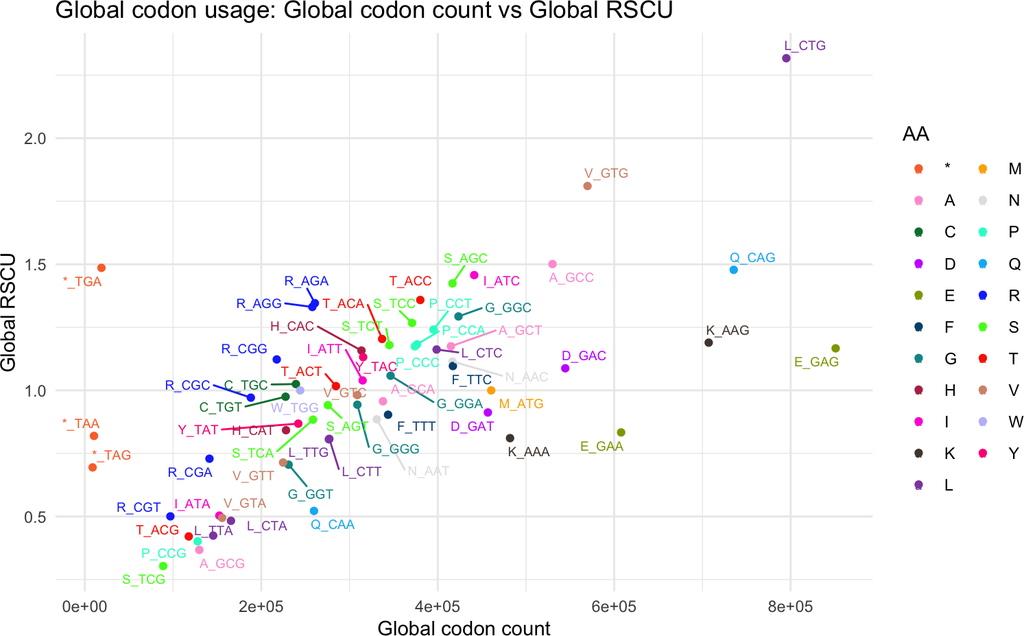

```r
plot_global_codon_usage(csm,
                        x_axis = "count",
                        y_axis = "rscu")
```

We can compare global codon usage patterns between two genomes.

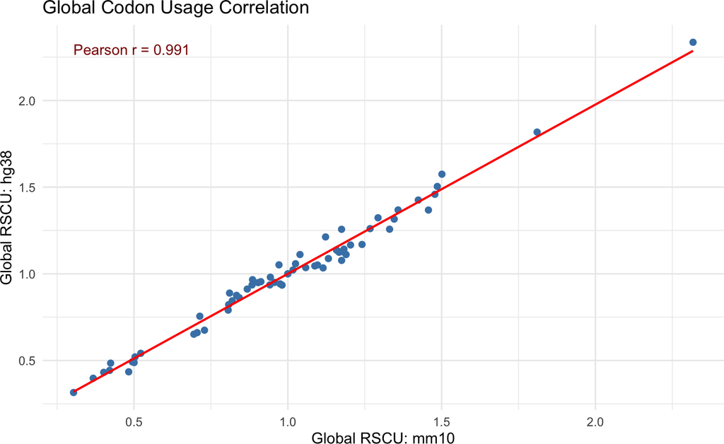

```r
plot_global_codon_usage_corr(csm, csh, metric = "rscu")
```

#### 4.3.3.2 Plot2: Top transcripts

- per-transcript metrics

For per-transcript metrics like “enc”, “cai”, and “milc”, bar plots can be used to visualize the transcripts with top values.

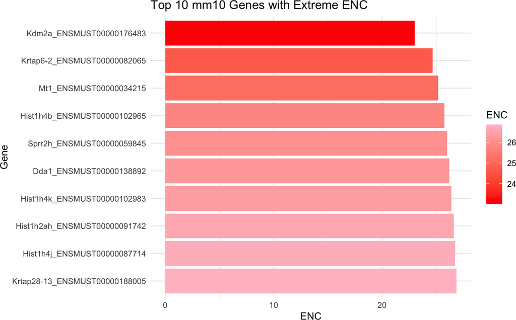

```r
# Plot transcripts with the top 10 lowest ENC
plot_metric_top(csm,
                metric = "enc",
                top = 10)
```

In addition, we can visualize the distribution of these metric values across all transcript to gain a broader overview of codon usage bias.

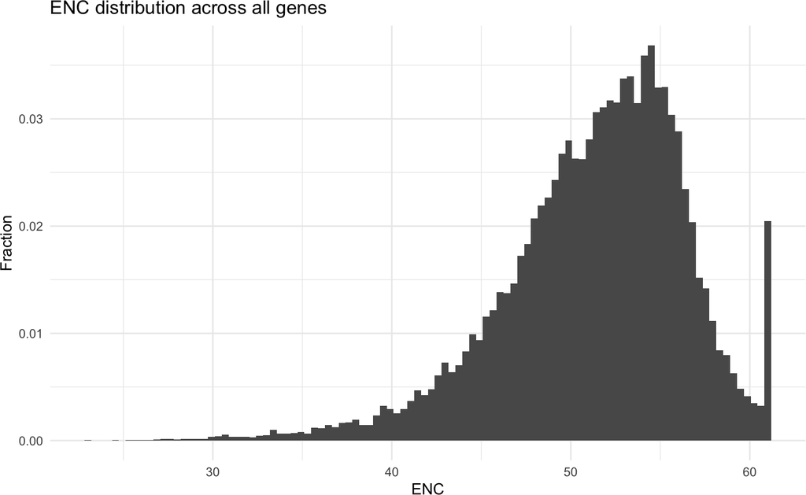

```r
plot_metric_dist(csm, metric = "enc")
```

- per-codon metrics

For codon-level metrics like raw counts and rscu, we can visualize, for selected codons, the top transcripts most enriched with those codons.

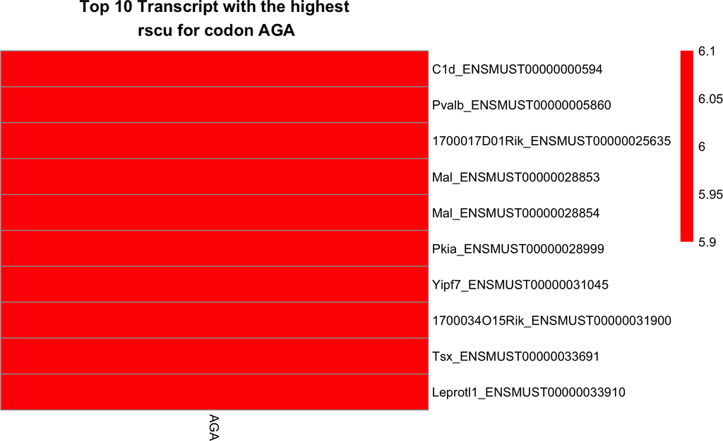

```r
plot_metric_per_codon(csm,
                      codon = "AGA",
                      top_n = 10,
                      by = "rscu")
```

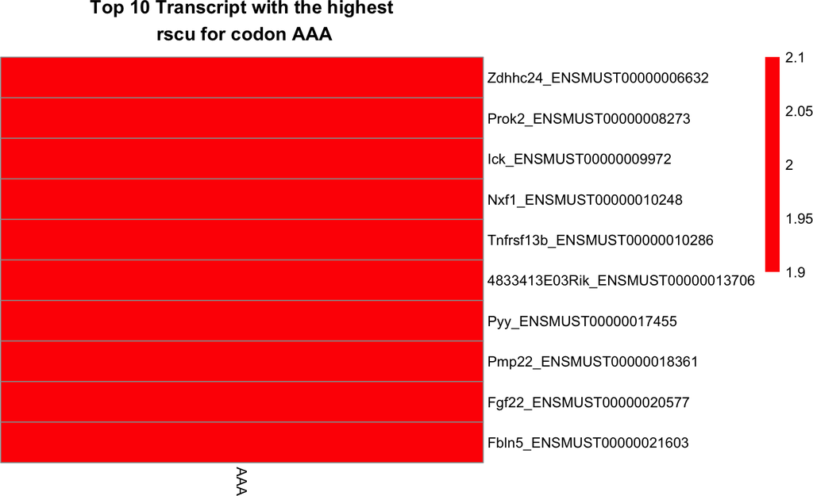

```r
# If multiple codons are specified, a list of plots will be returned
p_list <- plot_metric_per_codon(csm,
                                codon = c("AAA", "TTT"),
                                top_n = 10,
                                by = "rscu")
p_list$AAA
```

Plots can be saved by specifying the `outdir` argument.

#### 4.3.3.3 Plot3: Codon enrichment

For codon-level metrics, we can also use heatmap to visualize codon enrichment patterns across transcripts.

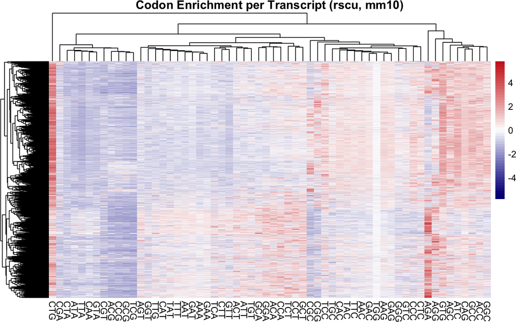

```r
plot_codon_enrichment(csm, metric = "rscu")
```

## 4.4 Step4: Compute pathway-level codon usage

Similar to transcript-level codon usage, metrics such as enc, enc_prime, cai, milc, and rscu can be computed at the pathway level by aggregating all transcripts with each pathway.

To perform pathway-level calculations, pathway information must first be added using `set_pathway_info()`. For demonstration, only five random pathways are added. By default, `pathway_ids = NULL`, and all available pathway information for the genome is retrieved from the KEGGREST database. The fetched pathway data is stored in the `pathway_info` slot.

```r
# Add pathway information for 5 random pathways
csm <- set_pathway_info(csm,
                        pathway_ids = c("mmu04110", "mmu04151",
                        "mmu04010", "mmu04660", "mmu00010"))
```

```
##  Retrieving pathway info ...
##   Pathway(s) to retrieve: 5
##  Retrieving pathway info: done!
```

```r
# View the added pathway information
pathway_info(csm) %>% head()
```

```
## # A tibble: 6 × 4
##   GENEID             ENTREZ_ID PATHWAY_ID PATHWAY_NAME
##   <chr>                  <int> <chr>      <chr>
## 1 ENSMUSG00000034021    100710 mmu04110   Cell cycle - Mus musculus (house mous…
## 2 ENSMUSG00000014859    104394 mmu04110   Cell cycle - Mus musculus (house mous…
## 3 ENSMUSG00000022369    105837 mmu04110   Cell cycle - Mus musculus (house mous…
## 4 ENSMUSG00000058290    105988 mmu04110   Cell cycle - Mus musculus (house mous…
## 5 ENSMUSG00000006398    107995 mmu04110   Cell cycle - Mus musculus (house mous…
## 6 ENSMUSG00000026842     11350 mmu04110   Cell cycle - Mus musculus (house mous…
```

Next, pathway-level metrics can be computed using `set_codon_usage_pathway()`. This updates the `codon_usage` slot with the newly calculated pathway-level metrics. For example, the `per_pathway` tibble contains the pathway-level codon counts, and the `per_pathway_rscu` holds the corresponding pathway-level RSCU values.

```r
csm <- set_codon_usage_pathway(csm, metric = "rscu")

# View pathway-level codon counts
codon_usage(csm)[["per_pathway"]] %>%
  head()
```

```
## # A tibble: 5 × 66
##   PATHWAY_ID PATHWAY_NAME    TTT   TTC   TTA   TTG   CTT   CTC   CTA   CTG   ATT
##   <chr>      <chr>         <int> <int> <int> <int> <int> <int> <int> <int> <int>
## 1 mmu00010   Glycolysis /…   817  1146   158   565   495  1024   283  2294  1007
## 2 mmu04010   MAPK signali…  7371 10985  2601  5675  4880  9471  3369 19227  6790
## 3 mmu04110   Cell cycle -…  3034  2436  1995  2693  2742  2591  1454  5303  3059
## 4 mmu04151   PI3K-Akt sig…  6721  9032  2527  5527  5180  8847  3158 17642  6451
## 5 mmu04660   T cell recep…  2507  2848  1118  1943  1764  2795  1106  5370  2410
## # ℹ 55 more variables: ATC <int>, ATA <int>, ATG <int>, GTT <int>, GTC <int>,
## #   GTA <int>, GTG <int>, TCT <int>, TCC <int>, TCA <int>, TCG <int>,
## #   AGT <int>, AGC <int>, CCT <int>, CCC <int>, CCA <int>, CCG <int>,
## #   ACT <int>, ACC <int>, ACA <int>, ACG <int>, GCT <int>, GCC <int>,
## #   GCA <int>, GCG <int>, TAT <int>, TAC <int>, TAA <int>, TAG <int>,
## #   TGA <int>, CAT <int>, CAC <int>, CAA <int>, CAG <int>, AAT <int>,
## #   AAC <int>, AAA <int>, AAG <int>, GAT <int>, GAC <int>, GAA <int>, …
```

```r
# View pathway-level RSCU values
codon_usage(csm)[["per_pathway_rscu"]] %>%
  head()
```

```
## # A tibble: 5 × 66
##   PATHWAY_ID PATHWAY_NAME    TTT   TTC   TTA   TTG   CTT   CTC   CTA   CTG   ATT
##   <chr>      <chr>         <dbl> <dbl> <dbl> <dbl> <dbl> <dbl> <dbl> <dbl> <dbl>
## 1 mmu00010   Glycolysis /… 0.832 1.17  0.197 0.703 0.616 1.27  0.352  2.86 1.02
## 2 mmu04010   MAPK signali… 0.803 1.20  0.345 0.753 0.647 1.26  0.447  2.55 0.921
## 3 mmu04110   Cell cycle -… 1.11  0.891 0.713 0.963 0.981 0.927 0.520  1.90 1.25
## 4 mmu04151   PI3K-Akt sig… 0.853 1.15  0.354 0.773 0.725 1.24  0.442  2.47 0.996
## 5 mmu04660   T cell recep… 0.936 1.06  0.476 0.827 0.751 1.19  0.471  2.29 1.03
## # ℹ 55 more variables: ATC <dbl>, ATA <dbl>, ATG <dbl>, GTT <dbl>, GTC <dbl>,
## #   GTA <dbl>, GTG <dbl>, TCT <dbl>, TCC <dbl>, TCA <dbl>, TCG <dbl>,
## #   AGT <dbl>, AGC <dbl>, CCT <dbl>, CCC <dbl>, CCA <dbl>, CCG <dbl>,
## #   ACT <dbl>, ACC <dbl>, ACA <dbl>, ACG <dbl>, GCT <dbl>, GCC <dbl>,
## #   GCA <dbl>, GCG <dbl>, TAT <dbl>, TAC <dbl>, TAA <dbl>, TAG <dbl>,
## #   TGA <dbl>, CAT <dbl>, CAC <dbl>, CAA <dbl>, CAG <dbl>, AAT <dbl>,
## #   AAC <dbl>, AAA <dbl>, AAG <dbl>, GAT <dbl>, GAC <dbl>, GAA <dbl>, …
```

### 4.4.1 Visualize pathway-level codon usage patterns

Similar to transcript-level codon usage patterns, we can visualize the codon usage patterns at the pathway level.

#### 4.4.1.1 Plot1: Top pathways

- per-transcript metrics

As in Step 3, per-transcript metrics such as enc, cai, and milc can be visualized using bar plots to highlight pathways with top metric values by setting `level = "pathway"`.

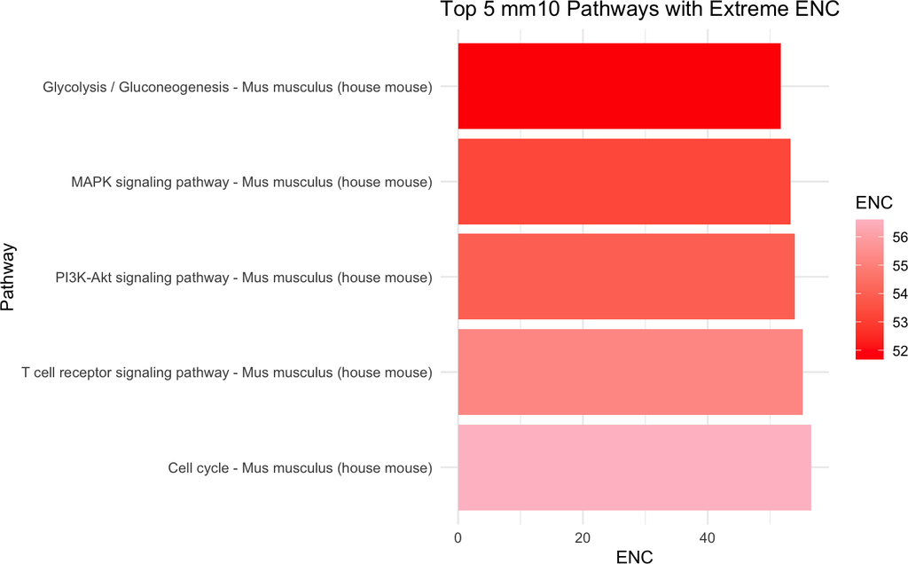

```r
# Plot transcripts with the top five lowest ENC
csm <- set_codon_usage_pathway(csm, metric = "enc")
plot_metric_top(csm,
                metric = "enc",
                level = "pathway",
                top = 5)
```

Also, we can visualize the distribution of these metric values across all pathways to gain an overview of codon usage variation at the pathway level.

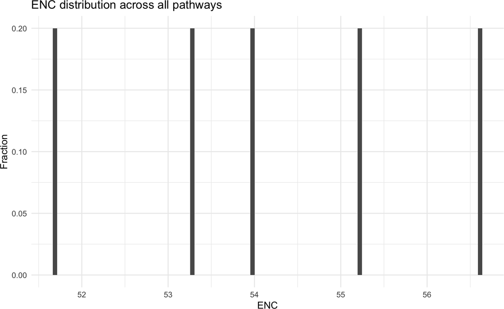

```r
plot_metric_dist(csm, metric = "enc", level = "pathway")
```

- per-codon metrics

For codon-level metrics like raw counts and rscu, we can visualize, for selected codons, the top pathways enriched with those codons.

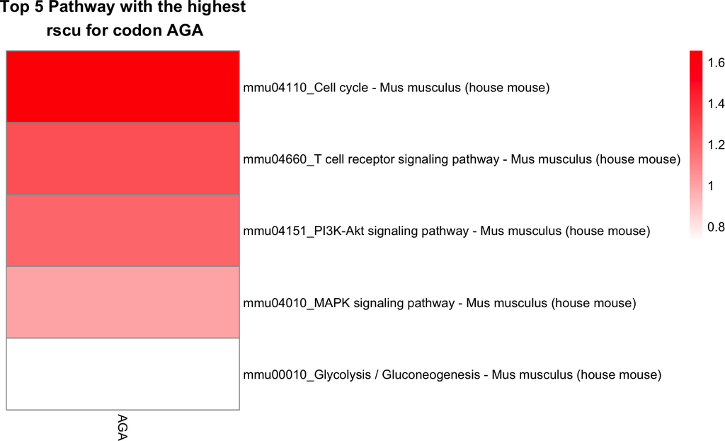

```r
plot_metric_per_codon(csm,
                      codon = "AGA",
                      top_n = 5,
                      level = "pathway",
                      by = "rscu")
```

#### 4.4.1.2 Plot2: Codon enrichment

As in Step 3, codon-level metrics including raw counts, normalized counts, and rscu, can be visualized using heatmaps to reveal codon enrichment patterns at the pathway level.

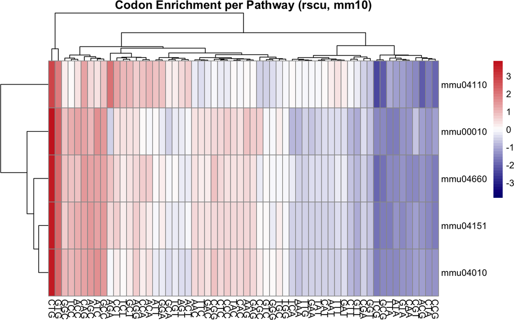

```r
plot_codon_enrichment(csm,
                      metric = "rscu",
                      level = "pathway",
                      label_row = TRUE,
                      downsample = 1)
```

#### 4.4.1.3 Plot3: Differentially used codons (DUCs)

- Scenario 1: Pathway-level DUCs against background

To identify differentially used codons (DUCs) at the pathway level, we can compare the pathway-level codon usage (e.g. rscu) against the background codon usage, e.g., the global codon usage. DUCs identified this way reflect the codon preferences of a specific pathway relative to the genomic average. P-values can be calculated using either Fisher’s exact test or the Chi-squared test. The results are stored in the `pathway_duc` slot.

```r
csm <- set_pathway_duc(csm)
```

```
##  Calculating pathway DUC ...
##  Calculating pathway DUC: done!
```

```r
# View the pathway-level DUCs
pathway_duc(csm) %>% head()
```

```
## # A tibble: 6 × 14
##   PATHWAY_ID PATHWAY_NAME        CODON RSCU_PATHWAY RSCU_GLOBAL FC_RSCU   PVALUE
##   <chr>      <chr>               <chr>        <dbl>       <dbl>   <dbl>    <dbl>
## 1 mmu00010   Glycolysis / Gluco… TTT          0.832       0.903   0.921 1.59e- 3
## 2 mmu00010   Glycolysis / Gluco… TTC          1.17        1.10    1.06  1.59e- 3
## 3 mmu00010   Glycolysis / Gluco… TTA          0.197       0.424   0.464 8.61e-30
## 4 mmu00010   Glycolysis / Gluco… TTG          0.703       0.806   0.873 4.45e- 4
## 5 mmu00010   Glycolysis / Gluco… CTT          0.616       0.808   0.763 2.27e-11
## 6 mmu00010   Glycolysis / Gluco… CTC          1.27        1.16    1.10  1.09e- 3
## # ℹ 7 more variables: PADJ <dbl>, COUNT_PATHWAY <dbl>, COUNT_GLOBAL <dbl>,
## #   AA <chr>, COUNT_SYN_PATHWAY <dbl>, COUNT_SYN_GLOBAL <dbl>, GENOME <chr>
```

To visualize pathway-level DUCs, we can use `plot_pathway_duc()`. By default, this function generates a heatmap showing the rscu fold change of each codon relative to the global background for each pathway.

```
## Plotting heatmap for pathway DUCs for 5 pathways.
## Plotting heatmap for pathway DUCs: done!
```

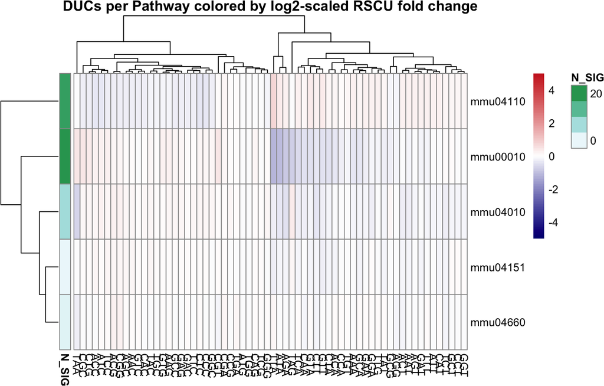

```r
plot_pathway_duc(csm)
```

We can also generate volcano plots for each pathway by setting `type = "volcano"`.

```r
p_list <- plot_pathway_duc(csm, type = "volcano")
```

```
## Plotting volcano plot for pathway DUCs for 5 pathways.
## Plotting volcano plot for pathway DUCs: done!
```

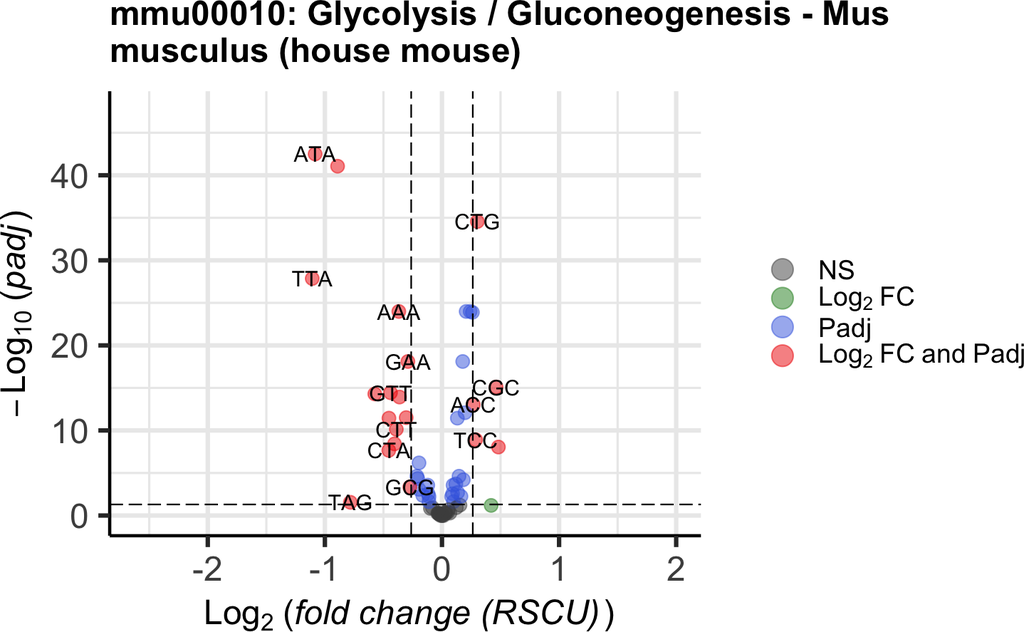

```r
p_list[[1]]
```

By setting the `outdir` parameter, plots will be saved to the specified directory. By setting the `outcsv` parameter, intermediate results will be saved as a CSV file. Additionally, use the `pathway_id` argument to generate plots for selected pathways only.

```
## Plotting volcano plot for pathway DUCs for 1 pathways.
## Plotting volcano plot for pathway DUCs: done!
```

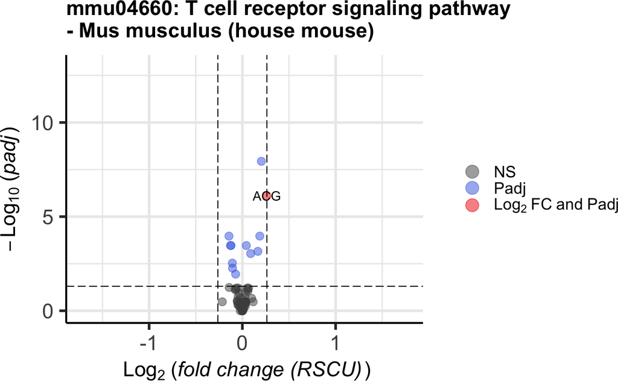

```r
plot_pathway_duc(csm,
                 type = "volcano",
                 pathway_id = "mmu04660")
```

- Scenario 2: Pathway-level DUCs between two conditions

Instead of comparing against the background codon usage, we can compare two `CodonStats` objects to identify DUCs at the pathway level. This approach enables detection of pathways enriched for specific codons in one condition relative to the other. For more details, see Use Case 1 below.

# 5 Use Case 1

In this example, we aim to identify pathways enriched with specific codons in one condition compared to another. We leverage the same TPM files as in Step 3, which are prepared from a RNA-seq dataset of mouse ESCs (GSE174492). Specifically, we will compare the WT1 condition against the KO1 condition to find differentially used codons (DUCs) at the pathway level.

```r
# Add pathway information
  # Here we only add 5 random pathways for demonstration
pathway_ids = c("mmu04110", "mmu04151", "mmu04010",
                "mmu04660", "mmu00010")
csm <- set_pathway_info(csm, pathway_ids = pathway_ids)
```

```
##  Retrieving pathway info ...
##   Pathway(s) to retrieve: 5
##  Retrieving pathway info: done!
```

```r
# Add TPM information
wt1_tpm <- system.file("extdata", "tpm/wt1_tpm.sf", package = "CodonProfiler")
ko1_tpm <- system.file("extdata", "tpm/ko1_tpm.sf", package = "CodonProfiler")
csm_wt1_tpm <- set_tpm(csm, tpm = wt1_tpm)
csm_ko1_tpm <- set_tpm(csm, tpm = ko1_tpm)

# Calculate pathway-level codon usage
  # Without TPM weighting
csm <- set_codon_usage(csm, use_tpm_weighted = FALSE)
csm <- set_codon_usage_pathway(csm, metric = "rscu")

  # With TPM weighting
csm_wt1_tpm <- set_codon_usage(csm_wt1_tpm, use_tpm_weighted = TRUE)
```

```
## Note: number of transcripts with TPM > 0: 19479/37927.
```

```r
csm_wt1_tpm <- set_codon_usage_pathway(csm_wt1_tpm, metric = "rscu")
csm_ko1_tpm <- set_codon_usage(csm_ko1_tpm, use_tpm_weighted = TRUE)
```

```
## Note: number of transcripts with TPM > 0: 18995/37927.
```

```r
csm_ko1_tpm <- set_codon_usage_pathway(csm_ko1_tpm, metric = "rscu")
```

Now, for each of the `csm`, `csm_wt1_tpm`, and `csm_ko1_tpm` objects, pathway-level DUCs can be calculated against their respective global backgrounds and visualized separately.

```r
csm <- set_pathway_duc(csm)
```

```
##  Calculating pathway DUC ...
##  Calculating pathway DUC: done!
```

```r
csm_wt1_tpm <- set_pathway_duc(csm_wt1_tpm)
```

```
##  Calculating pathway DUC ...
##  Calculating pathway DUC: done!
```

```r
csm_ko1_tpm <- set_pathway_duc(csm_ko1_tpm)
```

```
##  Calculating pathway DUC ...
##  Calculating pathway DUC: done!
```

```
## Plotting heatmap for pathway DUCs for 5 pathways.
## Plotting heatmap for pathway DUCs: done!
```

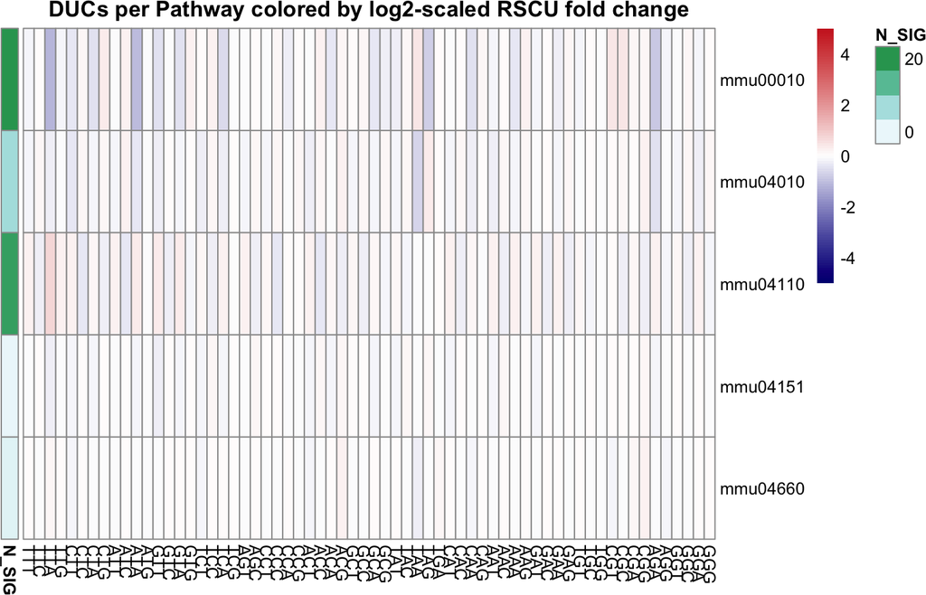

```r
plot_pathway_duc(csm,
                 cluster_rows = FALSE,
                 cluster_cols = FALSE)
```

```
## Plotting heatmap for pathway DUCs for 5 pathways.
## Plotting heatmap for pathway DUCs: done!
```

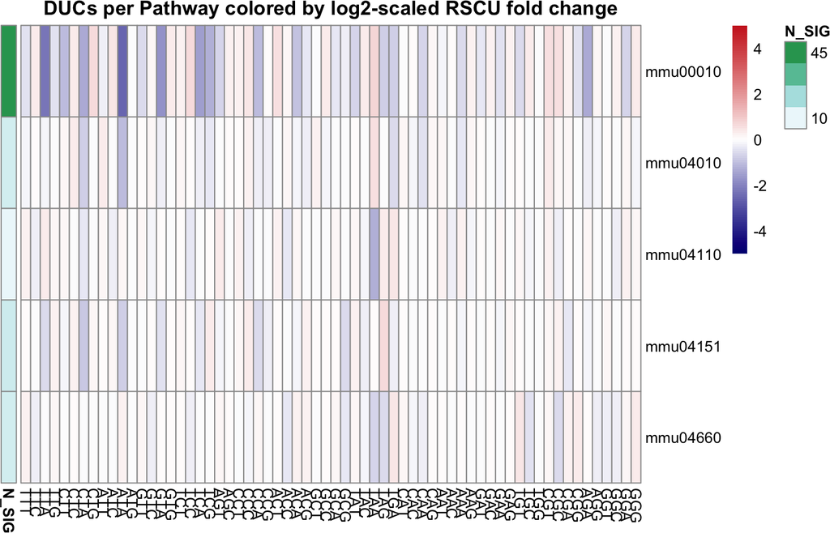

```r
plot_pathway_duc(csm_wt1_tpm,
                 cluster_rows = FALSE,
                 cluster_cols = FALSE)
```

```
## Plotting heatmap for pathway DUCs for 5 pathways.
## Plotting heatmap for pathway DUCs: done!
```

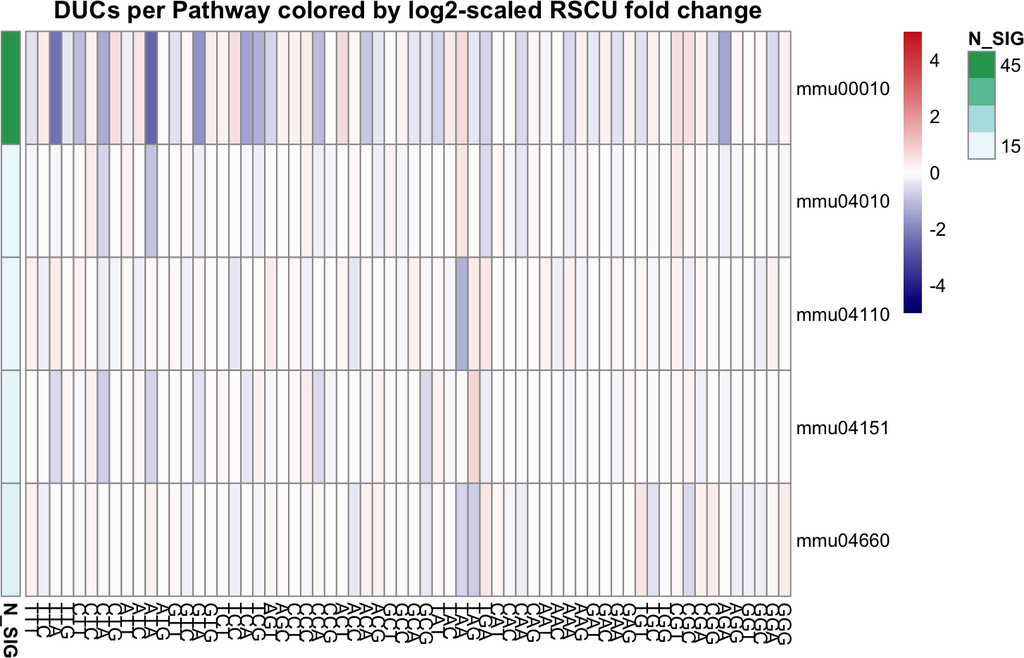

```r
plot_pathway_duc(csm_ko1_tpm,
                 cluster_rows = FALSE,
                 cluster_cols = FALSE)
```

It is clear that TPM-weighting significantly influences the pathway-level DUC results. The heatmap patterns for WT1 and KO1 against their respective global backgrounds appear similar. We can further compare WT1 directly to KO1 to identify pathway-level DUCs using the `find_pathway_duc()` function.

Unlike `set_pathway_duc()`, which calculates DUCs relative to the global background, `find_pathway_duc()` compares two `CodonStats` objects at the pathway level to identify DUCs. The fold change is calculated as the ratio of rscu values from the first `CodonStats` object divided by those from the second. The results are stored in a `PathwayDUC` object, which can be inspected using the `pathway_duc()` function.

```r
pathway_duc <- find_pathway_duc(csm_ko1_tpm, csm_wt1_tpm)
```

```
## Found 5 pathways that are present in both x and y.
## Finding pathway DUCs...
## Finding pathway DUCs: done!
```

```r
pathway_duc(pathway_duc) %>% head()
```

```
## # A tibble: 6 × 14
##   PATHWAY_ID CODON RSCU_PATHWAY_1 RSCU_PATHWAY_2 FC_RSCU  PVALUE   PADJ
##   <chr>      <chr>          <dbl>          <dbl>   <dbl>   <dbl>  <dbl>
## 1 mmu00010   TTT           0.663           0.662   1.00  0.935   0.992
## 2 mmu00010   TTC           1.34            1.34    1.000 0.935   0.992
## 3 mmu00010   TTA           0.0910          0.100   0.908 0.00125 0.0136
## 4 mmu00010   TTG           0.614           0.601   1.02  0.0680  0.171
## 5 mmu00010   CTT           0.399           0.398   1.00  0.927   0.992
## 6 mmu00010   CTC           1.28            1.30    0.983 0.0220  0.0740
## # ℹ 7 more variables: COUNT_PATHWAY_1 <dbl>, AA <chr>, COUNT_PATHWAY_2 <dbl>,
## #   COUNT_SYN_PATHWAY_1 <dbl>, COUNT_SYN_PATHWAY_2 <dbl>, PATHWAY_NAME <chr>,
## #   GENOME <chr>
```

The DUCs can also be visualized with `plot_pathway_duc()`.

```
## Plotting heatmap for pathway DUCs for 5 pathways.
## Plotting heatmap for pathway DUCs: done!
```

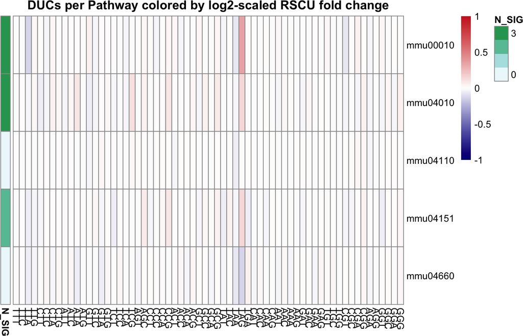

```r
plot_pathway_duc(pathway_duc,
                 type = "heatmap",
                 fc = 1.05,
                 padj = 0.05,
                 cluster_rows = FALSE,
                 cluster_cols = FALSE,
                 color_breaks = c(-1, 1))
```

It can be observed that there are three significant DUCs for the pathway “mmu00010” and “mmu04010” using `padj = 0.05` and `fc = 1.05`. These DUCs can be visualized with volcano plots by setting `type = "volcano"`.

```
## Plotting volcano plot for pathway DUCs for 1 pathways.
## Plotting volcano plot for pathway DUCs: done!
```

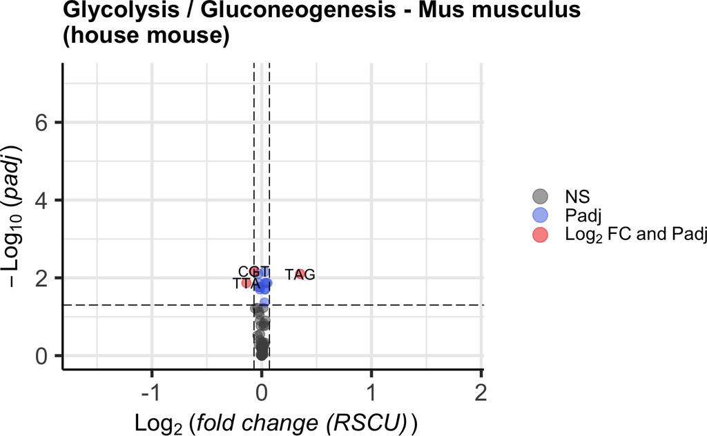

```r
plot_pathway_duc(pathway_duc,
                 type = "volcano",
                 pathway_id = "mmu00010",
                 fc = 1.05,
                 padj = 0.05)
```

The above plots show that the codons “CGT” (Arg) and “TTA” (Leu) are significantly less favored in the KO1 condition compared to the WT1 condition within the “mmu00010” pathway.